# Feature selection modelling with forester

Hubert Ruczyński

2023-05-28

# 1 Initialization

# 2 Read data

Firstly, let’s read the preprocessed datasets from three directories, each obtaining different results from the previous stage. The `preprocessed_raw` dataset contains the results with only preprocessing methods used, `preprocessed_freq_001` additionally took only those features that had more than 0.001 non zero values (thus, they weren’t insanely sparse), `preprocessed_freq_01_MI` had a higher frequency treshold at 0.01 and contained also the method for feature selection with the usage of mutual information.

```r
raw_names <- list.files(path = "preprocessed_raw/", pattern = "*.csv")
raw_list <- lapply(paste0("preprocessed_raw/", raw_names), read.csv)
names(raw_list) <- raw_names

freq_001_names <- list.files(path = "preprocessed_freq_001/", pattern = "*.csv")
freq_001_list <- lapply(paste0("preprocessed_freq_001/", freq_001_names), read.csv)
names(freq_001_list) <- freq_001_names

freq_01_names <- list.files(path = "preprocessed_freq_01_MI/", pattern = "*.csv")
freq_01_list <- lapply(paste0("preprocessed_freq_01_MI/", freq_01_names), read.csv)
names(freq_01_list) <- freq_01_names

for (i in 1:length(raw_list)) {
  raw_list[[i]]        <- raw_list[[i]][, !names(raw_list[[i]]) %in% c('X')]
}
for (i in 1:length(freq_001_list)) {
  freq_001_list[[i]]   <- freq_001_list[[i]][, !names(freq_001_list[[i]]) %in% c('X')]
}
for (i in 1:length(freq_01_list)) {
  freq_01_list[[i]] <- freq_01_list[[i]][, !names(freq_01_list[[i]]) %in% c('X')]
}
```

# 3 Metrics

In this section we prepare the functions to calculate the performance metrics used in this notebook.

```r
get_metrics <- function(observed, predictions) {
  models_frame           <- data.frame(matrix(nrow = length(predictions), ncol = 4))

  observed <- as.numeric(observed)
  for (i in 1:length(predictions)) {
    tp = sum((observed == 1) * (as.numeric(unlist(predictions[[i]])) >= 0.5))
    fp = sum((observed <= 0) * (as.numeric(unlist(predictions[[i]])) >= 0.5))
    tn = sum((observed <= 0) * (as.numeric(unlist(predictions[[i]])) < 0.5))
    fn = sum((observed == 1) * (as.numeric(unlist(predictions[[i]])) < 0.5))
    models_frame[i, ] <- c(names(predictions)[i],
                           model_performance_sensitivity(tp, fp, tn, fn),
                           model_performance_specificity(tp, fp, tn, fn),
                           model_performance_balanced_accuracy(tp, fp, tn, fn))
  }

  names(models_frame) <- c('name', 'sensitivity', 'specificity', 'balanced_accuracy')
  models_frame <- models_frame[order(models_frame$balanced_accuracy, decreasing = TRUE), ]
  return(models_frame)
}



model_performance_sensitivity <- function(tp, fp, tn, fn) {
  (tp) / (tp + fn)
}

model_performance_specificity <- function(tp, fp, tn, fn) {
  (tn) / (fp + tn)
}

model_performance_balanced_accuracy <- function(tp, fp, tn, fn) {
  (model_performance_sensitivity(tp, fp, tn, fn) + model_performance_specificity(tp, fp, tn, fn)) / 2
}
```

# 4 Box plot function

This section introduces a function for drawing the box plots comparing the balanced accuracies for different approaches.

```r
boxplot <- function(out, dataset, preprocessing) {
  df_names <- c()
  df_ba    <- c()

  for (i in 1:length(out)) {
    name   <- names(out)[i]
    if (dataset == 'spam') {
      name <- substr(name, 11, (nchar(name) - 4))
    }else if(dataset == 'artificial') {
      name <- substr(name, 17, (nchar(name) - 4))
    }

    df_names <- c(df_names, rep(name, 10))
    df_ba    <- c(df_ba, as.numeric(out[[i]]$balanced_accuracy))
  }

  plot_df <- data.frame(name = df_names, balanced_accuracy = df_ba)

  ggplot(plot_df, aes(x = df_names, y = df_ba)) +
    geom_boxplot(alpha = 0.5) +
    theme_minimal() +
    labs(title = 'Boxplot of the balanced acuracy between different datasets',
         subtitle = paste0('for ', dataset, ' dataset and ', preprocessing,' preprocessing'),
         x = 'Dataset name',
         y = 'Balanced Accuracy') +
    theme(plot.title = element_text(colour = 'black', size = 25),
          axis.title.x = element_text(colour = 'black', size = 15),
          axis.title.y = element_text(colour = 'black', size = 15))
}
```

# 5 forester training

In our approach, to obtain the best possible results from the prepared datasets, we’ve decided to use an AutoML package called the `forester`, where Hubert is the main developer and maintainer. The forester offers us a fast and simple training of the tree-based models, such as random forest, decision tree, xgboost, and lightgbm. This model family proves to be excellent for the datasets with small number of features, what perfectly matches with our datasets where we’ve selected the most prominent columns. As we cannot set the balanced accuracy metric as the optimization metric for the Bayesian optimization, we’ve decided to turn it off, and calculate dozens of models with the usage of the Random Search algorithm. To ensure the same splits, we’ve set the same split seed for all experiments, and we’ve divided a training dataset into training and testing subsets, to estimate the final performance.

## 5.1 Parameters

```r
Engine = c('ranger', 'xgboost', 'decision_tree', 'lightgbm') #catboost takes too long to calculate
Verbose = FALSE
Train_test_split = c(0.8, 0.199, 0.001)
Split_seed = 2137
Bayes_iter = 0
Random_evals = 50
Advanced_preprocessing = FALSE
Metrics = 'all'
Sort_by = 'balanced_accuracy'
```

## 5.2 Function

This function trains the models from a given set of dataframes.

```r
multi_train <- function(data) {
  df_names <- names(data)
  art_no   <- 0

  for (i in 1:length(data)) {
    if(grepl('artificial',  df_names[i])) {
      art_no <- art_no + 1
    }
  }

  spam_no <- length(data) - art_no

  if (art_no != 0) {
    art  <- data[1:art_no]
  } else {
    art  <- NULL
  }

  spam <- data[(art_no + 1): length(data)]

  art_models     <- list()
  art_preds      <- list()
  art_best_preds <- list()
  art_metrics    <- list()

  if (art_no != 0) {
    art_k <- length(art) / 2
    for (i in 1:art_k) {
      art_models[[i]]  <- train(data = art[[i + art_k]],
                                y = 'TARGET',
                                engine = Engine,
                                verbose = Verbose,
                                train_test_split = Train_test_split,
                                split_seed = Split_seed,
                                bayes_iter = Bayes_iter,
                                random_evals = Random_evals,
                                advanced_preprocessing = Advanced_preprocessing,
                                metrics = Metrics,
                                sort_by = Sort_by)

      art_preds[[i]]      <- predict_new(art_models[[i]], art[[i]])
      art_best_preds[[i]] <- art_preds[[i]][head(art_models[[i]]$score_test$name, 10)]
      art_metrics[[i]]    <- get_metrics(art[[i]]$TARGET, art_best_preds[[i]])
    }

    names(art_metrics) <- df_names[1:art_k]

  } else {
    art_metrics <- NULL
  }

  spam_models     <- list()
  spam_preds      <- list()
  spam_best_preds <- list()
  spam_metrics    <- list()

  if (spam_no != 0) {
    spam_k <- length(spam) / 2
    for (i in 1:spam_k) {
      spam_models[[i]] <- train(data = spam[[i + spam_k]],
                                y = 'TARGET',
                                engine = Engine,
                                verbose = Verbose,
                                train_test_split = Train_test_split,
                                split_seed = Split_seed,
                                bayes_iter = Bayes_iter,
                                random_evals = Random_evals,
                                advanced_preprocessing = Advanced_preprocessing,
                                metrics = Metrics,
                                sort_by = Sort_by)

      spam_preds[[i]]      <- predict_new(spam_models[[i]], spam[[i]])
      spam_best_preds[[i]] <- spam_preds[[i]][head(spam_models[[i]]$score_test$name, 10)]
      spam_metrics[[i]]    <- get_metrics(spam[[i]]$TARGET, spam_best_preds[[i]])
    }

    names(spam_metrics) <- df_names[(art_no + 1):(art_no + spam_k)]

  } else {
    spam_metrics <- NULL
  }

  return(list(
    art_metrics  = art_metrics,
    spam_metrics = spam_metrics
  ))

}
```

## 5.3 Training

Whole training lasts around half an hour on a high quality gaming PC.

```r
tryCatch({
      freq_01_out  <- readRDS('cached_results/freq_01_out.RData')
      freq_001_out <- readRDS('cached_results/freq_001_out.RData')
      raw_list_out <- readRDS('cached_results/raw_list_out.RData')
    },
    error = function(cond) {
      tic(cat('Frequency 01 data training \n'))
      freq_01_out  <- multi_train(freq_01_list)
      toc()
      tic(cat('Frequency 001 data training \n'))
      freq_001_out <- multi_train(freq_001_list)
      toc()
      tic(cat('Raw data training \n'))
      raw_list_out <- multi_train(raw_list)
      toc()

      saveRDS(freq_01_out, 'cached_results/freq_01_out.RData')
      saveRDS(freq_001_out, 'cached_results/freq_001_out.RData')
      saveRDS(raw_list_out, 'cached_results/raw_list_out.RData')
      }
    )
```

# 6 Spam results

In this section we present results for the spam dataset.

## 6.1 Raw list

```r
for (i in 1:length(raw_list_out$spam_metrics)) {
  cat('\n', names(raw_list_out$spam_metrics)[i], '\n')
  print(kable(raw_list_out$spam_metrics[[i]]))
}
```

spam_test_boruta_36.csv

|  | name | sensitivity | specificity | balanced_accuracy |
| --- | --- | --- | --- | --- |
| 4 | lightgbm_RS_1 | 0.829268292682927 | 0.993686868686869 | 0.911477580684898 |
| 1 | lightgbm_model | 0.813008130081301 | 0.987373737373737 | 0.900190933727519 |
| 6 | lightgbm_RS_19 | 0.804878048780488 | 0.984848484848485 | 0.894863266814486 |
| 3 | lightgbm_RS_21 | 0.796747967479675 | 0.988636363636364 | 0.892692165558019 |
| 2 | lightgbm_RS_3 | 0.796747967479675 | 0.987373737373737 | 0.892060852426706 |
| 7 | lightgbm_RS_15 | 0.796747967479675 | 0.987373737373737 | 0.892060852426706 |
| 8 | lightgbm_RS_23 | 0.796747967479675 | 0.983585858585859 | 0.890166913032767 |
| 5 | xgboost_RS_26 | 0.780487804878049 | 0.988636363636364 | 0.884562084257206 |
| 9 | ranger_RS_7 | 0.75609756097561 | 0.993686868686869 | 0.874892214831239 |
| 10 | ranger_RS_14 | 0.75609756097561 | 0.991161616161616 | 0.873629588568613 |

spam_test_feature_importance_100.csv

|  | name | sensitivity | specificity | balanced_accuracy |
| --- | --- | --- | --- | --- |
| 7 | lightgbm_RS_19 | 0.813008130081301 | 0.986111111111111 | 0.899559620596206 |
| 8 | lightgbm_model | 0.804878048780488 | 0.992424242424242 | 0.898651145602365 |
| 2 | lightgbm_RS_21 | 0.796747967479675 | 0.992424242424242 | 0.894586104951959 |
| 6 | xgboost_RS_26 | 0.788617886178862 | 0.98989898989899 | 0.889258438038926 |
| 10 | lightgbm_RS_15 | 0.780487804878049 | 0.987373737373737 | 0.883930771125893 |
| 9 | lightgbm_RS_23 | 0.772357723577236 | 0.987373737373737 | 0.879865730475487 |
| 5 | ranger_RS_14 | 0.747967479674797 | 1 | 0.873983739837398 |
| 1 | ranger_model | 0.739837398373984 | 0.998737373737374 | 0.869287386055679 |
| 4 | ranger_RS_44 | 0.739837398373984 | 0.998737373737374 | 0.869287386055679 |
| 3 | ranger_RS_7 | 0.715447154471545 | 0.998737373737374 | 0.857092264104459 |

spam_test_feature_importance_150.csv

|  | name | sensitivity | specificity | balanced_accuracy |
| --- | --- | --- | --- | --- |
| 4 | lightgbm_RS_3 | 0.813008130081301 | 0.98989898989899 | 0.901453559990145 |
| 2 | lightgbm_RS_21 | 0.813008130081301 | 0.988636363636364 | 0.900822246858832 |
| 10 | lightgbm_RS_23 | 0.813008130081301 | 0.984848484848485 | 0.898928307464893 |
| 3 | lightgbm_model | 0.804878048780488 | 0.98989898989899 | 0.897388519339739 |
| 9 | lightgbm_RS_1 | 0.804878048780488 | 0.98989898989899 | 0.897388519339739 |
| 5 | lightgbm_RS_15 | 0.796747967479675 | 0.991161616161616 | 0.893954791820645 |
| 7 | lightgbm_RS_19 | 0.788617886178862 | 0.986111111111111 | 0.887364498644986 |
| 1 | xgboost_RS_26 | 0.75609756097561 | 0.994949494949495 | 0.875523527962552 |
| 8 | ranger_model | 0.715447154471545 | 0.998737373737374 | 0.857092264104459 |
| 6 | ranger_RS_14 | 0.707317073170732 | 0.998737373737374 | 0.853027223454053 |

spam_test_feature_importance_50.csv

|  | name | sensitivity | specificity | balanced_accuracy |
| --- | --- | --- | --- | --- |
| 10 | lightgbm_RS_3 | 0.804878048780488 | 0.981060606060606 | 0.892969327420547 |
| 5 | lightgbm_RS_19 | 0.804878048780488 | 0.978535353535353 | 0.891706701157921 |
| 8 | lightgbm_RS_23 | 0.796747967479675 | 0.984848484848485 | 0.89079822616408 |
| 1 | lightgbm_model | 0.796747967479675 | 0.981060606060606 | 0.88890428677014 |
| 2 | lightgbm_RS_21 | 0.780487804878049 | 0.984848484848485 | 0.882668144863267 |
| 7 | lightgbm_RS_1 | 0.780487804878049 | 0.981060606060606 | 0.880774205469327 |
| 4 | xgboost_RS_26 | 0.764227642276423 | 0.97979797979798 | 0.872012811037201 |
| 3 | ranger_model | 0.747967479674797 | 0.993686868686869 | 0.870827174180833 |
| 6 | ranger_RS_28 | 0.707317073170732 | 0.996212121212121 | 0.851764597191426 |
| 9 | ranger_RS_39 | 0.691056910569106 | 0.997474747474748 | 0.844265829021927 |

spam_test_mrmr_100.csv

|  | name | sensitivity | specificity | balanced_accuracy |
| --- | --- | --- | --- | --- |
| 2 | lightgbm_RS_1 | 0.804878048780488 | 0.977272727272727 | 0.891075388026608 |
| 8 | lightgbm_RS_21 | 0.796747967479675 | 0.984848484848485 | 0.89079822616408 |
| 6 | lightgbm_RS_3 | 0.788617886178862 | 0.984848484848485 | 0.886733185513673 |
| 7 | lightgbm_model | 0.780487804878049 | 0.981060606060606 | 0.880774205469327 |
| 5 | lightgbm_RS_23 | 0.780487804878049 | 0.978535353535353 | 0.879511579206701 |
| 3 | xgboost_RS_26 | 0.772357723577236 | 0.983585858585859 | 0.877971791081547 |
| 4 | lightgbm_RS_15 | 0.772357723577236 | 0.97979797979798 | 0.876077851687608 |
| 1 | lightgbm_RS_19 | 0.764227642276423 | 0.978535353535353 | 0.871381497905888 |
| 10 | lightgbm_RS_20 | 0.75609756097561 | 0.982323232323232 | 0.869210396649421 |
| 9 | ranger_model | 0.731707317073171 | 0.996212121212121 | 0.863959719142646 |

spam_test_mrmr_150.csv

|  | name | sensitivity | specificity | balanced_accuracy |
| --- | --- | --- | --- | --- |
| 2 | lightgbm_RS_21 | 0.796747967479675 | 0.982323232323232 | 0.889535599901454 |
| 1 | lightgbm_RS_1 | 0.796747967479675 | 0.97979797979798 | 0.888272973638827 |
| 4 | lightgbm_RS_15 | 0.796747967479675 | 0.976010101010101 | 0.886379034244888 |
| 6 | lightgbm_model | 0.788617886178862 | 0.982323232323232 | 0.885470559251047 |
| 3 | lightgbm_RS_19 | 0.788617886178862 | 0.981060606060606 | 0.884839246119734 |
| 7 | lightgbm_RS_3 | 0.788617886178862 | 0.978535353535353 | 0.883576619857108 |
| 8 | lightgbm_RS_23 | 0.772357723577236 | 0.97979797979798 | 0.876077851687608 |
| 5 | xgboost_RS_26 | 0.723577235772358 | 0.982323232323232 | 0.852950234047795 |
| 9 | ranger_model | 0.699186991869919 | 1 | 0.849593495934959 |
| 10 | ranger_RS_44 | 0.682926829268293 | 1 | 0.841463414634146 |

spam_test_mrmr_50.csv

|  | name | sensitivity | specificity | balanced_accuracy |
| --- | --- | --- | --- | --- |
| 1 | ranger_RS_28 | 0.691056910569106 | 0.993686868686869 | 0.842371889627987 |
| 2 | ranger_model | 0.67479674796748 | 0.992424242424242 | 0.833610495195861 |
| 3 | ranger_RS_7 | 0.67479674796748 | 0.992424242424242 | 0.833610495195861 |
| 8 | ranger_RS_44 | 0.67479674796748 | 0.984848484848485 | 0.829822616407982 |
| 4 | ranger_RS_14 | 0.666666666666667 | 0.992424242424242 | 0.829545454545455 |
| 5 | ranger_RS_35 | 0.666666666666667 | 0.992424242424242 | 0.829545454545455 |
| 9 | ranger_RS_29 | 0.658536585365854 | 0.988636363636364 | 0.823586474501109 |
| 7 | ranger_RS_43 | 0.650406504065041 | 0.993686868686869 | 0.822046686375955 |
| 10 | ranger_RS_12 | 0.650406504065041 | 0.993686868686869 | 0.822046686375955 |
| 6 | ranger_RS_39 | 0.650406504065041 | 0.992424242424242 | 0.821415373244642 |

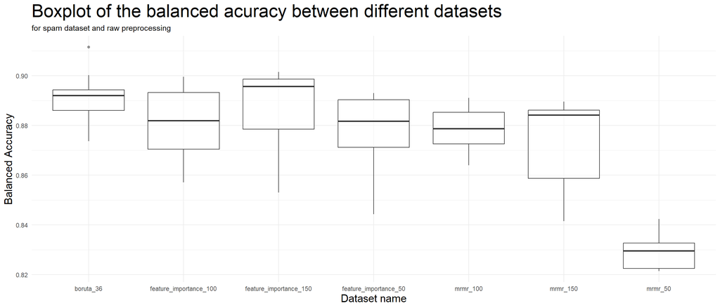

```r
boxplot(raw_list_out$spam_metrics, 'spam', 'raw')
```

As we can see, for the basic approach,we can see that the BORUTA algorithm achieved an astonishing result with a single outlier which gained over 91% of balanced accuracy.

Second best selection method is the feature importance selection based on the trees, where the performance was the better, the more features were left for the training. The same we can say about the worst method called MRMR, moreover in this case we can witness a huge difference between the method with 100 and 50 features.

## 6.2 At least 0.001 frequency

```r
for (i in 1:length(freq_001_out$spam_metrics)) {
  cat('\n', names(freq_001_out$spam_metrics)[i], '\n')
  print(kable(freq_001_out$spam_metrics[[i]]))
}
```

spam_test_boruta_26.csv

|  | name | sensitivity | specificity | balanced_accuracy |
| --- | --- | --- | --- | --- |
| 7 | lightgbm_RS_22 | 0.780487804878049 | 0.981060606060606 | 0.880774205469327 |
| 6 | lightgbm_RS_1 | 0.772357723577236 | 0.987373737373737 | 0.879865730475487 |
| 3 | lightgbm_RS_3 | 0.772357723577236 | 0.986111111111111 | 0.879234417344174 |
| 4 | lightgbm_RS_21 | 0.772357723577236 | 0.986111111111111 | 0.879234417344174 |
| 5 | xgboost_RS_26 | 0.772357723577236 | 0.981060606060606 | 0.876709164818921 |
| 1 | lightgbm_RS_19 | 0.75609756097561 | 0.983585858585859 | 0.869841709780734 |
| 10 | lightgbm_RS_20 | 0.75609756097561 | 0.982323232323232 | 0.869210396649421 |
| 2 | lightgbm_model | 0.747967479674797 | 0.986111111111111 | 0.867039295392954 |
| 9 | xgboost_model | 0.731707317073171 | 0.991161616161616 | 0.861434466617393 |
| 8 | lightgbm_RS_15 | 0.739837398373984 | 0.982323232323232 | 0.861080315348608 |

spam_test_chi2_100.csv

|  | name | sensitivity | specificity | balanced_accuracy |
| --- | --- | --- | --- | --- |
| 5 | lightgbm_RS_1 | 0.788617886178862 | 0.986111111111111 | 0.887364498644986 |
| 6 | lightgbm_RS_19 | 0.788617886178862 | 0.983585858585859 | 0.88610187238236 |
| 8 | lightgbm_RS_3 | 0.788617886178862 | 0.983585858585859 | 0.88610187238236 |
| 3 | lightgbm_RS_15 | 0.788617886178862 | 0.97979797979798 | 0.884207932988421 |
| 4 | lightgbm_RS_21 | 0.780487804878049 | 0.986111111111111 | 0.88329945799458 |
| 10 | lightgbm_model | 0.772357723577236 | 0.986111111111111 | 0.879234417344174 |
| 1 | xgboost_RS_26 | 0.764227642276423 | 0.983585858585859 | 0.873906750431141 |
| 7 | lightgbm_RS_23 | 0.764227642276423 | 0.981060606060606 | 0.872644124168514 |
| 2 | ranger_model | 0.699186991869919 | 0.997474747474748 | 0.848330869672333 |
| 9 | ranger_RS_28 | 0.666666666666667 | 0.998737373737374 | 0.83270202020202 |

spam_test_chi2_150.csv

|  | name | sensitivity | specificity | balanced_accuracy |
| --- | --- | --- | --- | --- |
| 6 | lightgbm_RS_1 | 0.813008130081301 | 0.98989898989899 | 0.901453559990145 |
| 5 | lightgbm_model | 0.796747967479675 | 0.992424242424242 | 0.894586104951959 |
| 1 | lightgbm_RS_3 | 0.796747967479675 | 0.987373737373737 | 0.892060852426706 |
| 4 | xgboost_RS_26 | 0.788617886178862 | 0.98989898989899 | 0.889258438038926 |
| 3 | lightgbm_RS_23 | 0.788617886178862 | 0.986111111111111 | 0.887364498644986 |
| 9 | lightgbm_RS_21 | 0.780487804878049 | 0.993686868686869 | 0.887087336782459 |
| 7 | lightgbm_RS_19 | 0.780487804878049 | 0.991161616161616 | 0.885824710519832 |
| 2 | lightgbm_RS_15 | 0.780487804878049 | 0.987373737373737 | 0.883930771125893 |
| 10 | ranger_RS_14 | 0.699186991869919 | 0.998737373737374 | 0.848962182803646 |
| 8 | ranger_RS_44 | 0.691056910569106 | 0.997474747474748 | 0.844265829021927 |

spam_test_chi2_50.csv

|  | name | sensitivity | specificity | balanced_accuracy |
| --- | --- | --- | --- | --- |
| 4 | lightgbm_RS_21 | 0.804878048780488 | 0.983585858585859 | 0.894231953683173 |
| 5 | lightgbm_model | 0.804878048780488 | 0.983585858585859 | 0.894231953683173 |
| 6 | lightgbm_RS_3 | 0.796747967479675 | 0.982323232323232 | 0.889535599901454 |
| 2 | lightgbm_RS_1 | 0.788617886178862 | 0.982323232323232 | 0.885470559251047 |
| 7 | lightgbm_RS_23 | 0.780487804878049 | 0.982323232323232 | 0.881405518600641 |
| 3 | lightgbm_RS_15 | 0.780487804878049 | 0.97979797979798 | 0.880142892338014 |
| 1 | lightgbm_RS_19 | 0.780487804878049 | 0.978535353535353 | 0.879511579206701 |
| 9 | xgboost_RS_26 | 0.764227642276423 | 0.97979797979798 | 0.872012811037201 |
| 8 | ranger_model | 0.723577235772358 | 0.996212121212121 | 0.859894678492239 |
| 10 | ranger_RS_12 | 0.723577235772358 | 0.982323232323232 | 0.852950234047795 |

spam_test_feature_importance_100.csv

|  | name | sensitivity | specificity | balanced_accuracy |
| --- | --- | --- | --- | --- |
| 4 | lightgbm_RS_21 | 0.821138211382114 | 0.98989898989899 | 0.905518600640552 |
| 7 | lightgbm_RS_19 | 0.813008130081301 | 0.98989898989899 | 0.901453559990145 |
| 10 | lightgbm_RS_15 | 0.804878048780488 | 0.98989898989899 | 0.897388519339739 |
| 6 | lightgbm_RS_3 | 0.796747967479675 | 0.98989898989899 | 0.893323478689332 |
| 3 | lightgbm_RS_1 | 0.796747967479675 | 0.986111111111111 | 0.891429539295393 |
| 2 | lightgbm_model | 0.788617886178862 | 0.991161616161616 | 0.889889751170239 |
| 9 | lightgbm_RS_23 | 0.788617886178862 | 0.988636363636364 | 0.888627124907613 |
| 5 | xgboost_RS_26 | 0.772357723577236 | 0.991161616161616 | 0.881759669869426 |
| 1 | lightgbm_RS_26 | 0.764227642276423 | 0.986111111111111 | 0.875169376693767 |
| 8 | ranger_RS_7 | 0.723577235772358 | 0.998737373737374 | 0.861157304754866 |

spam_test_feature_importance_150.csv

|  | name | sensitivity | specificity | balanced_accuracy |
| --- | --- | --- | --- | --- |
| 7 | lightgbm_RS_1 | 0.821138211382114 | 0.98989898989899 | 0.905518600640552 |
| 9 | lightgbm_RS_15 | 0.796747967479675 | 0.994949494949495 | 0.895848731214585 |
| 5 | lightgbm_model | 0.796747967479675 | 0.993686868686869 | 0.895217418083272 |
| 3 | lightgbm_RS_21 | 0.796747967479675 | 0.991161616161616 | 0.893954791820645 |
| 2 | lightgbm_RS_3 | 0.788617886178862 | 0.994949494949495 | 0.891783690564178 |
| 1 | xgboost_RS_26 | 0.780487804878049 | 0.994949494949495 | 0.887718649913772 |
| 4 | lightgbm_RS_23 | 0.780487804878049 | 0.994949494949495 | 0.887718649913772 |
| 8 | ranger_model | 0.723577235772358 | 0.998737373737374 | 0.861157304754866 |
| 10 | ranger_RS_28 | 0.723577235772358 | 0.997474747474748 | 0.860525991623553 |
| 6 | ranger_RS_7 | 0.715447154471545 | 0.998737373737374 | 0.857092264104459 |

spam_test_feature_importance_50.csv

|  | name | sensitivity | specificity | balanced_accuracy |
| --- | --- | --- | --- | --- |
| 3 | lightgbm_RS_21 | 0.83739837398374 | 0.991161616161616 | 0.914279995072678 |
| 8 | lightgbm_model | 0.821138211382114 | 0.988636363636364 | 0.904887287509239 |
| 2 | lightgbm_RS_1 | 0.821138211382114 | 0.987373737373737 | 0.904255974377926 |
| 9 | lightgbm_RS_3 | 0.813008130081301 | 0.98989898989899 | 0.901453559990145 |
| 5 | lightgbm_RS_23 | 0.813008130081301 | 0.984848484848485 | 0.898928307464893 |
| 1 | xgboost_RS_26 | 0.780487804878049 | 0.991161616161616 | 0.885824710519832 |
| 7 | ranger_model | 0.75609756097561 | 0.994949494949495 | 0.875523527962552 |
| 6 | ranger_RS_44 | 0.739837398373984 | 0.994949494949495 | 0.867393446661739 |
| 10 | ranger_RS_35 | 0.731707317073171 | 0.998737373737374 | 0.865222345405272 |
| 4 | ranger_RS_28 | 0.731707317073171 | 0.996212121212121 | 0.863959719142646 |

spam_test_mrmr_100.csv

|  | name | sensitivity | specificity | balanced_accuracy |
| --- | --- | --- | --- | --- |
| 3 | lightgbm_RS_21 | 0.796747967479675 | 0.982323232323232 | 0.889535599901454 |
| 2 | lightgbm_RS_1 | 0.796747967479675 | 0.97979797979798 | 0.888272973638827 |
| 5 | lightgbm_RS_15 | 0.796747967479675 | 0.976010101010101 | 0.886379034244888 |
| 6 | lightgbm_model | 0.788617886178862 | 0.982323232323232 | 0.885470559251047 |
| 4 | lightgbm_RS_19 | 0.788617886178862 | 0.981060606060606 | 0.884839246119734 |
| 7 | lightgbm_RS_3 | 0.788617886178862 | 0.978535353535353 | 0.883576619857108 |
| 8 | lightgbm_RS_23 | 0.772357723577236 | 0.97979797979798 | 0.876077851687608 |
| 1 | xgboost_RS_26 | 0.75609756097561 | 0.97979797979798 | 0.867947770386795 |
| 9 | ranger_model | 0.723577235772358 | 0.997474747474748 | 0.860525991623553 |
| 10 | ranger_RS_14 | 0.707317073170732 | 0.998737373737374 | 0.853027223454053 |

spam_test_mrmr_150.csv

|  | name | sensitivity | specificity | balanced_accuracy |
| --- | --- | --- | --- | --- |
| 4 | lightgbm_RS_1 | 0.813008130081301 | 0.986111111111111 | 0.899559620596206 |
| 8 | lightgbm_RS_19 | 0.813008130081301 | 0.983585858585859 | 0.89829699433358 |
| 6 | lightgbm_RS_21 | 0.796747967479675 | 0.988636363636364 | 0.892692165558019 |
| 5 | lightgbm_RS_3 | 0.796747967479675 | 0.983585858585859 | 0.890166913032767 |
| 2 | lightgbm_RS_15 | 0.796747967479675 | 0.982323232323232 | 0.889535599901454 |
| 1 | lightgbm_RS_23 | 0.788617886178862 | 0.986111111111111 | 0.887364498644986 |
| 7 | lightgbm_model | 0.788617886178862 | 0.986111111111111 | 0.887364498644986 |
| 3 | xgboost_RS_26 | 0.75609756097561 | 0.984848484848485 | 0.870473022912047 |
| 9 | ranger_RS_28 | 0.682926829268293 | 0.997474747474748 | 0.84020078837152 |
| 10 | ranger_RS_35 | 0.67479674796748 | 1 | 0.83739837398374 |

spam_test_mrmr_50.csv

|  | name | sensitivity | specificity | balanced_accuracy |
| --- | --- | --- | --- | --- |
| 10 | lightgbm_RS_21 | 0.796747967479675 | 0.97979797979798 | 0.888272973638827 |
| 2 | ranger_model | 0.739837398373984 | 0.994949494949495 | 0.867393446661739 |
| 7 | ranger_RS_14 | 0.739837398373984 | 0.992424242424242 | 0.866130820399113 |
| 8 | ranger_RS_44 | 0.731707317073171 | 0.994949494949495 | 0.863328406011333 |
| 3 | ranger_RS_7 | 0.723577235772358 | 0.997474747474748 | 0.860525991623553 |
| 4 | ranger_RS_28 | 0.723577235772358 | 0.997474747474748 | 0.860525991623553 |
| 5 | ranger_RS_35 | 0.715447154471545 | 0.994949494949495 | 0.85519832471052 |
| 1 | ranger_RS_43 | 0.707317073170732 | 0.996212121212121 | 0.851764597191426 |
| 6 | ranger_RS_39 | 0.699186991869919 | 0.997474747474748 | 0.848330869672333 |
| 9 | ranger_RS_40 | 0.682926829268293 | 0.997474747474748 | 0.84020078837152 |

spam_test_mutual_information_100.csv

|  | name | sensitivity | specificity | balanced_accuracy |
| --- | --- | --- | --- | --- |
| 5 | lightgbm_RS_21 | 0.83739837398374 | 0.996212121212121 | 0.91680524759793 |
| 7 | lightgbm_RS_23 | 0.83739837398374 | 0.992424242424242 | 0.914911308203991 |
| 3 | lightgbm_RS_3 | 0.829268292682927 | 0.994949494949495 | 0.912108893816211 |
| 2 | lightgbm_model | 0.821138211382114 | 0.996212121212121 | 0.908675166297118 |
| 9 | lightgbm_RS_1 | 0.821138211382114 | 0.992424242424242 | 0.906781226903178 |
| 4 | lightgbm_RS_19 | 0.813008130081301 | 0.996212121212121 | 0.904610125646711 |
| 6 | xgboost_RS_26 | 0.804878048780488 | 0.98989898989899 | 0.897388519339739 |
| 1 | ranger_model | 0.747967479674797 | 1 | 0.873983739837398 |
| 8 | ranger_RS_28 | 0.699186991869919 | 0.998737373737374 | 0.848962182803646 |
| 10 | ranger_RS_44 | 0.699186991869919 | 0.994949494949495 | 0.847068243409707 |

spam_test_mutual_information_50.csv

|  | name | sensitivity | specificity | balanced_accuracy |
| --- | --- | --- | --- | --- |
| 1 | lightgbm_RS_19 | 0.804878048780488 | 0.984848484848485 | 0.894863266814486 |
| 8 | lightgbm_RS_3 | 0.804878048780488 | 0.984848484848485 | 0.894863266814486 |
| 3 | lightgbm_RS_21 | 0.796747967479675 | 0.986111111111111 | 0.891429539295393 |
| 4 | lightgbm_model | 0.796747967479675 | 0.984848484848485 | 0.89079822616408 |
| 5 | lightgbm_RS_15 | 0.780487804878049 | 0.983585858585859 | 0.882036831731954 |
| 2 | xgboost_RS_26 | 0.780487804878049 | 0.982323232323232 | 0.881405518600641 |
| 6 | lightgbm_RS_23 | 0.780487804878049 | 0.982323232323232 | 0.881405518600641 |
| 7 | lightgbm_RS_1 | 0.780487804878049 | 0.982323232323232 | 0.881405518600641 |
| 9 | lightgbm_RS_26 | 0.764227642276423 | 0.982323232323232 | 0.873275437299828 |
| 10 | ranger_RS_14 | 0.723577235772358 | 0.993686868686869 | 0.858632052229613 |

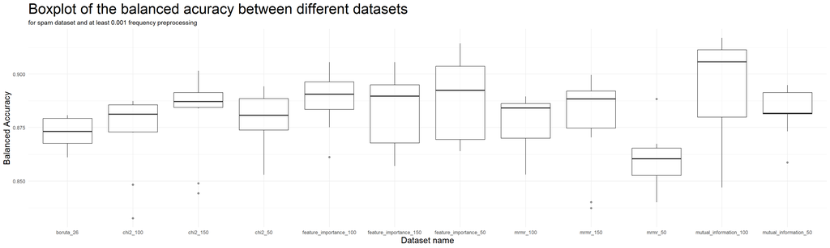

```r
boxplot(freq_001_out$spam_metrics, 'spam', 'at least 0.001 frequency')
```

After the initial filtering we could add a feature selection method based on chi2 metric, however its performance was only better than MRMR. We can also witness a drastic decrease of performance for the BORUTA method, and a general mean decrease in the performance of the models.

There is a one outlier however that puts a different light on this case. The best performing model was an FI method using the mutual information, and its median results are far better than any other method, moreover it produced a best performing model with balanced accuracy equal 91.7%

## 6.3 At least 0.01 frequency

```r
for (i in 1:length(freq_01_out$spam_metrics)) {
  cat('\n', names(freq_01_out$spam_metrics)[i], '\n')
  print(kable(freq_01_out$spam_metrics[[i]]))
}
```

spam_test_boruta_28.csv

|  | name | sensitivity | specificity | balanced_accuracy |
| --- | --- | --- | --- | --- |
| 7 | lightgbm_RS_21 | 0.829268292682927 | 0.986111111111111 | 0.907689701897019 |
| 6 | lightgbm_model | 0.821138211382114 | 0.986111111111111 | 0.903624661246613 |
| 5 | lightgbm_RS_1 | 0.813008130081301 | 0.984848484848485 | 0.898928307464893 |
| 1 | lightgbm_RS_3 | 0.804878048780488 | 0.986111111111111 | 0.8954945799458 |
| 9 | lightgbm_RS_19 | 0.796747967479675 | 0.984848484848485 | 0.89079822616408 |
| 3 | lightgbm_RS_15 | 0.788617886178862 | 0.982323232323232 | 0.885470559251047 |
| 4 | xgboost_RS_26 | 0.788617886178862 | 0.982323232323232 | 0.885470559251047 |
| 2 | lightgbm_RS_23 | 0.780487804878049 | 0.97979797979798 | 0.880142892338014 |
| 8 | lightgbm_RS_20 | 0.75609756097561 | 0.982323232323232 | 0.869210396649421 |
| 10 | ranger_RS_12 | 0.682926829268293 | 0.984848484848485 | 0.833887657058389 |

spam_test_chi2_100.csv

|  | name | sensitivity | specificity | balanced_accuracy |
| --- | --- | --- | --- | --- |
| 3 | lightgbm_RS_3 | 0.845528455284553 | 0.992424242424242 | 0.918976348854398 |
| 4 | lightgbm_RS_19 | 0.845528455284553 | 0.98989898989899 | 0.917713722591771 |
| 6 | lightgbm_RS_21 | 0.83739837398374 | 0.992424242424242 | 0.914911308203991 |
| 1 | lightgbm_RS_1 | 0.83739837398374 | 0.98989898989899 | 0.913648681941365 |
| 2 | lightgbm_RS_15 | 0.829268292682927 | 0.991161616161616 | 0.910214954422272 |
| 8 | xgboost_RS_26 | 0.829268292682927 | 0.98989898989899 | 0.909583641290958 |
| 5 | lightgbm_model | 0.821138211382114 | 0.994949494949495 | 0.908043853165804 |
| 7 | lightgbm_RS_23 | 0.804878048780488 | 0.992424242424242 | 0.898651145602365 |
| 9 | lightgbm_RS_26 | 0.796747967479675 | 0.987373737373737 | 0.892060852426706 |
| 10 | ranger_RS_12 | 0.788617886178862 | 0.982323232323232 | 0.885470559251047 |

spam_test_chi2_150.csv

|  | name | sensitivity | specificity | balanced_accuracy |
| --- | --- | --- | --- | --- |
| 6 | lightgbm_RS_21 | 0.861788617886179 | 0.991161616161616 | 0.926475117023898 |
| 3 | lightgbm_RS_1 | 0.845528455284553 | 0.992424242424242 | 0.918976348854398 |
| 2 | lightgbm_model | 0.83739837398374 | 0.98989898989899 | 0.913648681941365 |
| 4 | lightgbm_RS_3 | 0.829268292682927 | 0.991161616161616 | 0.910214954422272 |
| 9 | xgboost_RS_26 | 0.821138211382114 | 0.993686868686869 | 0.907412540034491 |
| 1 | lightgbm_RS_19 | 0.804878048780488 | 0.993686868686869 | 0.899282458733678 |
| 8 | lightgbm_RS_26 | 0.804878048780488 | 0.987373737373737 | 0.896125893077113 |
| 7 | lightgbm_RS_23 | 0.796747967479675 | 0.993686868686869 | 0.895217418083272 |
| 10 | lightgbm_RS_20 | 0.796747967479675 | 0.986111111111111 | 0.891429539295393 |
| 5 | lightgbm_RS_15 | 0.772357723577236 | 0.991161616161616 | 0.881759669869426 |

spam_test_chi2_50.csv

|  | name | sensitivity | specificity | balanced_accuracy |
| --- | --- | --- | --- | --- |
| 2 | lightgbm_RS_1 | 0.853658536585366 | 0.991161616161616 | 0.922410076373491 |
| 4 | lightgbm_RS_21 | 0.853658536585366 | 0.987373737373737 | 0.920516136979552 |
| 6 | lightgbm_RS_3 | 0.845528455284553 | 0.98989898989899 | 0.917713722591771 |
| 7 | xgboost_RS_26 | 0.845528455284553 | 0.98989898989899 | 0.917713722591771 |
| 3 | lightgbm_RS_19 | 0.845528455284553 | 0.987373737373737 | 0.916451096329145 |
| 1 | lightgbm_model | 0.83739837398374 | 0.987373737373737 | 0.912386055678739 |
| 5 | lightgbm_RS_23 | 0.83739837398374 | 0.986111111111111 | 0.911754742547426 |
| 9 | ranger_RS_7 | 0.796747967479675 | 0.993686868686869 | 0.895217418083272 |
| 8 | lightgbm_RS_15 | 0.804878048780488 | 0.984848484848485 | 0.894863266814486 |
| 10 | ranger_model | 0.788617886178862 | 0.991161616161616 | 0.889889751170239 |

spam_test_feature_importance_100.csv

|  | name | sensitivity | specificity | balanced_accuracy |
| --- | --- | --- | --- | --- |
| 1 | lightgbm_RS_19 | 0.861788617886179 | 0.993686868686869 | 0.927737743286524 |
| 3 | lightgbm_RS_3 | 0.845528455284553 | 0.993686868686869 | 0.919607661985711 |
| 7 | lightgbm_RS_1 | 0.829268292682927 | 0.994949494949495 | 0.912108893816211 |
| 5 | lightgbm_model | 0.829268292682927 | 0.992424242424242 | 0.910846267553585 |
| 8 | lightgbm_RS_21 | 0.829268292682927 | 0.992424242424242 | 0.910846267553585 |
| 6 | xgboost_RS_26 | 0.829268292682927 | 0.991161616161616 | 0.910214954422272 |
| 9 | lightgbm_RS_20 | 0.821138211382114 | 0.987373737373737 | 0.904255974377926 |
| 10 | lightgbm_RS_26 | 0.813008130081301 | 0.986111111111111 | 0.899559620596206 |
| 2 | lightgbm_RS_15 | 0.796747967479675 | 0.997474747474748 | 0.897111357477211 |
| 4 | lightgbm_RS_23 | 0.796747967479675 | 0.994949494949495 | 0.895848731214585 |

spam_test_feature_importance_150.csv

|  | name | sensitivity | specificity | balanced_accuracy |
| --- | --- | --- | --- | --- |
| 2 | lightgbm_RS_19 | 0.861788617886179 | 0.993686868686869 | 0.927737743286524 |
| 5 | lightgbm_RS_21 | 0.861788617886179 | 0.991161616161616 | 0.926475117023898 |
| 1 | lightgbm_RS_3 | 0.845528455284553 | 0.996212121212121 | 0.920870288248337 |
| 4 | lightgbm_model | 0.83739837398374 | 0.992424242424242 | 0.914911308203991 |
| 8 | lightgbm_RS_1 | 0.829268292682927 | 0.98989898989899 | 0.909583641290958 |
| 10 | lightgbm_RS_20 | 0.829268292682927 | 0.987373737373737 | 0.908321015028332 |
| 7 | xgboost_RS_26 | 0.821138211382114 | 0.991161616161616 | 0.906149913771865 |
| 9 | lightgbm_RS_26 | 0.813008130081301 | 0.988636363636364 | 0.900822246858832 |
| 3 | lightgbm_RS_15 | 0.804878048780488 | 0.992424242424242 | 0.898651145602365 |
| 6 | lightgbm_RS_23 | 0.796747967479675 | 0.988636363636364 | 0.892692165558019 |

spam_test_feature_importance_50.csv

|  | name | sensitivity | specificity | balanced_accuracy |
| --- | --- | --- | --- | --- |
| 4 | lightgbm_model | 0.829268292682927 | 0.993686868686869 | 0.911477580684898 |
| 5 | lightgbm_RS_21 | 0.821138211382114 | 0.991161616161616 | 0.906149913771865 |
| 1 | lightgbm_RS_3 | 0.813008130081301 | 0.991161616161616 | 0.902084873121458 |
| 3 | lightgbm_RS_19 | 0.813008130081301 | 0.98989898989899 | 0.901453559990145 |
| 2 | xgboost_RS_26 | 0.804878048780488 | 0.992424242424242 | 0.898651145602365 |
| 7 | ranger_model | 0.788617886178862 | 0.991161616161616 | 0.889889751170239 |
| 6 | lightgbm_RS_15 | 0.788617886178862 | 0.98989898989899 | 0.889258438038926 |
| 8 | ranger_RS_7 | 0.780487804878049 | 0.992424242424242 | 0.886456023651146 |
| 10 | lightgbm_RS_20 | 0.780487804878049 | 0.986111111111111 | 0.88329945799458 |
| 9 | ranger_RS_35 | 0.772357723577236 | 0.991161616161616 | 0.881759669869426 |

spam_test_mrmr_100.csv

|  | name | sensitivity | specificity | balanced_accuracy |
| --- | --- | --- | --- | --- |
| 2 | lightgbm_RS_19 | 0.853658536585366 | 0.987373737373737 | 0.920516136979552 |
| 3 | lightgbm_RS_3 | 0.845528455284553 | 0.988636363636364 | 0.917082409460458 |
| 7 | lightgbm_RS_1 | 0.845528455284553 | 0.988636363636364 | 0.917082409460458 |
| 4 | lightgbm_RS_21 | 0.83739837398374 | 0.993686868686869 | 0.915542621335304 |
| 1 | lightgbm_model | 0.829268292682927 | 0.993686868686869 | 0.911477580684898 |
| 6 | xgboost_RS_26 | 0.821138211382114 | 0.992424242424242 | 0.906781226903178 |
| 8 | lightgbm_RS_23 | 0.821138211382114 | 0.98989898989899 | 0.905518600640552 |
| 5 | lightgbm_RS_15 | 0.821138211382114 | 0.987373737373737 | 0.904255974377926 |
| 10 | lightgbm_RS_20 | 0.813008130081301 | 0.984848484848485 | 0.898928307464893 |
| 9 | lightgbm_RS_26 | 0.796747967479675 | 0.988636363636364 | 0.892692165558019 |

spam_test_mrmr_150.csv

|  | name | sensitivity | specificity | balanced_accuracy |
| --- | --- | --- | --- | --- |
| 4 | lightgbm_RS_1 | 0.861788617886179 | 0.991161616161616 | 0.926475117023898 |
| 1 | lightgbm_RS_21 | 0.845528455284553 | 0.993686868686869 | 0.919607661985711 |
| 8 | lightgbm_model | 0.845528455284553 | 0.992424242424242 | 0.918976348854398 |
| 5 | lightgbm_RS_19 | 0.845528455284553 | 0.991161616161616 | 0.918345035723084 |
| 3 | lightgbm_RS_15 | 0.829268292682927 | 0.993686868686869 | 0.911477580684898 |
| 2 | lightgbm_RS_3 | 0.821138211382114 | 0.98989898989899 | 0.905518600640552 |
| 7 | xgboost_RS_26 | 0.813008130081301 | 0.993686868686869 | 0.903347499384085 |
| 6 | lightgbm_RS_23 | 0.804878048780488 | 0.996212121212121 | 0.900545084996305 |
| 9 | lightgbm_RS_26 | 0.788617886178862 | 0.984848484848485 | 0.886733185513673 |
| 10 | lightgbm_RS_25 | 0.75609756097561 | 0.98989898989899 | 0.8729982754373 |

spam_test_mrmr_50.csv

|  | name | sensitivity | specificity | balanced_accuracy |
| --- | --- | --- | --- | --- |
| 1 | lightgbm_RS_21 | 0.829268292682927 | 0.992424242424242 | 0.910846267553585 |
| 6 | xgboost_RS_26 | 0.829268292682927 | 0.992424242424242 | 0.910846267553585 |
| 7 | lightgbm_RS_1 | 0.821138211382114 | 0.994949494949495 | 0.908043853165804 |
| 5 | lightgbm_RS_19 | 0.821138211382114 | 0.992424242424242 | 0.906781226903178 |
| 2 | lightgbm_model | 0.821138211382114 | 0.991161616161616 | 0.906149913771865 |
| 4 | lightgbm_RS_23 | 0.813008130081301 | 0.991161616161616 | 0.902084873121458 |
| 3 | lightgbm_RS_3 | 0.804878048780488 | 0.992424242424242 | 0.898651145602365 |
| 10 | ranger_RS_7 | 0.796747967479675 | 0.996212121212121 | 0.896480044345898 |
| 8 | xgboost_model | 0.780487804878049 | 0.98989898989899 | 0.885193397388519 |
| 9 | lightgbm_RS_25 | 0.731707317073171 | 0.983585858585859 | 0.857646587829515 |

spam_test_mutual_information_100.csv

|  | name | sensitivity | specificity | balanced_accuracy |
| --- | --- | --- | --- | --- |
| 5 | lightgbm_model | 0.853658536585366 | 0.994949494949495 | 0.92430401576743 |
| 6 | lightgbm_RS_1 | 0.853658536585366 | 0.992424242424242 | 0.923041389504804 |
| 4 | lightgbm_RS_3 | 0.829268292682927 | 0.996212121212121 | 0.912740206947524 |
| 8 | lightgbm_RS_21 | 0.829268292682927 | 0.996212121212121 | 0.912740206947524 |
| 7 | xgboost_RS_26 | 0.813008130081301 | 0.991161616161616 | 0.902084873121458 |
| 2 | lightgbm_RS_15 | 0.804878048780488 | 0.991161616161616 | 0.898019832471052 |
| 1 | lightgbm_RS_19 | 0.796747967479675 | 0.993686868686869 | 0.895217418083272 |
| 10 | ranger_model | 0.788617886178862 | 0.997474747474748 | 0.893046316826805 |
| 9 | lightgbm_RS_23 | 0.772357723577236 | 0.996212121212121 | 0.884284922394678 |
| 3 | ranger_RS_12 | 0.764227642276423 | 0.984848484848485 | 0.874538063562454 |

spam_test_mutual_information_50.csv

|  | name | sensitivity | specificity | balanced_accuracy |
| --- | --- | --- | --- | --- |
| 2 | lightgbm_model | 0.869918699186992 | 0.98989898989899 | 0.929908844542991 |
| 5 | lightgbm_RS_1 | 0.861788617886179 | 0.986111111111111 | 0.923949864498645 |
| 3 | lightgbm_RS_3 | 0.853658536585366 | 0.987373737373737 | 0.920516136979552 |
| 7 | lightgbm_RS_19 | 0.845528455284553 | 0.987373737373737 | 0.916451096329145 |
| 8 | xgboost_RS_26 | 0.83739837398374 | 0.992424242424242 | 0.914911308203991 |
| 4 | lightgbm_RS_21 | 0.83739837398374 | 0.98989898989899 | 0.913648681941365 |
| 6 | lightgbm_RS_15 | 0.821138211382114 | 0.986111111111111 | 0.903624661246613 |
| 9 | ranger_model | 0.796747967479675 | 0.991161616161616 | 0.893954791820645 |
| 10 | ranger_RS_44 | 0.772357723577236 | 0.992424242424242 | 0.882390983000739 |
| 1 | lightgbm_RS_23 | 0.772357723577236 | 0.988636363636364 | 0.8804970436068 |

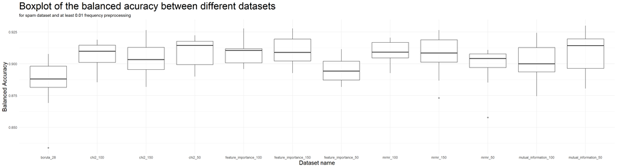

```r
boxplot(freq_01_out$spam_metrics, 'spam', 'at least 0.01 frequency')
```

The final example with a more rigorous filtering was a huge success, as most models have more than 90% of balanced accuracy. In this case, the mutual information method also proved to be the best, and we achieved the best model with 93% of balanced accuracy.

# 7 Artificial results

## 7.1 Raw list

```r
for (i in 1:length(raw_list_out$art_metrics)) {
  cat('\n', names(raw_list_out$art_metrics)[i], '\n')
  print(kable(raw_list_out$art_metrics[[i]]))
}
```

artificial_test_boruta_20.csv

|  | name | sensitivity | specificity | balanced_accuracy |
| --- | --- | --- | --- | --- |
| 9 | ranger_RS_20 | 0.875 | 0.875 | 0.875 |
| 4 | ranger_RS_11 | 0.875 | 0.87 | 0.8725 |
| 8 | ranger_model | 0.87 | 0.87 | 0.87 |
| 1 | ranger_RS_10 | 0.865 | 0.87 | 0.8675 |
| 7 | ranger_RS_22 | 0.875 | 0.86 | 0.8675 |
| 5 | ranger_RS_24 | 0.86 | 0.865 | 0.8625 |
| 10 | ranger_RS_46 | 0.855 | 0.87 | 0.8625 |
| 3 | ranger_RS_30 | 0.86 | 0.86 | 0.86 |
| 6 | ranger_RS_13 | 0.855 | 0.86 | 0.8575 |
| 2 | ranger_RS_12 | 0.85 | 0.845 | 0.8475 |

artificial_test_feature_importance_10.csv

|  | name | sensitivity | specificity | balanced_accuracy |
| --- | --- | --- | --- | --- |
| 6 | ranger_RS_11 | 0.81 | 0.83 | 0.82 |
| 10 | ranger_RS_24 | 0.805 | 0.83 | 0.8175 |
| 3 | xgboost_RS_47 | 0.815 | 0.815 | 0.815 |
| 5 | ranger_RS_12 | 0.81 | 0.82 | 0.815 |
| 7 | ranger_RS_30 | 0.79 | 0.84 | 0.815 |
| 1 | ranger_model | 0.8 | 0.825 | 0.8125 |
| 2 | ranger_RS_20 | 0.79 | 0.83 | 0.81 |
| 4 | ranger_RS_10 | 0.79 | 0.83 | 0.81 |
| 9 | lightgbm_model | 0.815 | 0.8 | 0.8075 |
| 8 | lightgbm_RS_9 | 0.785 | 0.825 | 0.805 |

artificial_test_feature_importance_5.csv

|  | name | sensitivity | specificity | balanced_accuracy |
| --- | --- | --- | --- | --- |
| 9 | ranger_RS_9 | 0.69 | 0.755 | 0.7225 |
| 8 | ranger_RS_34 | 0.68 | 0.75 | 0.715 |
| 6 | ranger_RS_24 | 0.665 | 0.76 | 0.7125 |
| 7 | ranger_RS_31 | 0.665 | 0.76 | 0.7125 |
| 5 | ranger_RS_36 | 0.675 | 0.745 | 0.71 |
| 1 | ranger_RS_37 | 0.665 | 0.75 | 0.7075 |
| 3 | ranger_RS_7 | 0.675 | 0.74 | 0.7075 |
| 2 | ranger_RS_28 | 0.675 | 0.735 | 0.705 |
| 10 | ranger_RS_48 | 0.7 | 0.7 | 0.7 |
| 4 | lightgbm_RS_22 | 0.675 | 0.705 | 0.69 |

artificial_test_mrmr_10.csv

|  | name | sensitivity | specificity | balanced_accuracy |
| --- | --- | --- | --- | --- |
| 9 | ranger_RS_37 | 0.605 | 0.645 | 0.625 |
| 4 | ranger_RS_7 | 0.58 | 0.655 | 0.6175 |
| 8 | ranger_RS_24 | 0.575 | 0.655 | 0.615 |
| 1 | ranger_RS_28 | 0.565 | 0.66 | 0.6125 |
| 3 | ranger_RS_40 | 0.56 | 0.655 | 0.6075 |
| 6 | ranger_RS_36 | 0.57 | 0.645 | 0.6075 |
| 2 | ranger_RS_11 | 0.58 | 0.63 | 0.605 |
| 5 | ranger_RS_46 | 0.56 | 0.65 | 0.605 |
| 7 | ranger_RS_13 | 0.57 | 0.63 | 0.6 |
| 10 | ranger_RS_42 | 0.56 | 0.635 | 0.5975 |

artificial_test_mrmr_5.csv

|  | name | sensitivity | specificity | balanced_accuracy |
| --- | --- | --- | --- | --- |
| 7 | xgboost_RS_19 | 0.46 | 0.77 | 0.615 |
| 8 | xgboost_RS_40 | 0.46 | 0.77 | 0.615 |
| 9 | xgboost_RS_48 | 0.46 | 0.77 | 0.615 |
| 10 | xgboost_RS_35 | 0.515 | 0.715 | 0.615 |
| 1 | xgboost_RS_6 | 0.505 | 0.72 | 0.6125 |
| 6 | xgboost_RS_34 | 0.45 | 0.775 | 0.6125 |
| 2 | xgboost_RS_21 | 0.38 | 0.78 | 0.58 |
| 3 | ranger_RS_22 | 0.54 | 0.61 | 0.575 |
| 5 | ranger_RS_43 | 0.57 | 0.575 | 0.5725 |
| 4 | ranger_RS_11 | 0.545 | 0.545 | 0.545 |

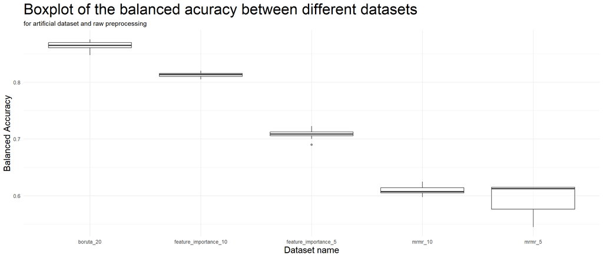

```r
boxplot(raw_list_out$art_metrics, 'artificial', 'raw')
```

For the artificial dataset, we didn’t have to explicitly filter the frequency for the chi2 test, as we’ve resigned from using this method. This dataset shows an incredible differences between various methods. The best one is the BORUTA, which selected 20 parameters, however it also provided highest balanced accuracy equal 0.875. Next method was less successful and with smaller number of features (not 10, but 5) the training results were even worse.. Finally, the MRMR obtained the worst results around 0.6.

## 7.2 At least 0.01 frequency

```r
for (i in 1:length(freq_01_out$art_metrics)) {
  cat('\n', names(freq_01_out$art_metrics)[i], '\n')
  print(knitr::kable(freq_01_out$art_metrics[[i]]))
}
```

artificial_test_mutual_information_10.csv

|  | name | sensitivity | specificity | balanced_accuracy |
| --- | --- | --- | --- | --- |
| 10 | ranger_RS_11 | 0.61 | 0.695 | 0.6525 |
| 1 | ranger_RS_20 | 0.615 | 0.685 | 0.65 |
| 3 | ranger_RS_10 | 0.605 | 0.68 | 0.6425 |
| 6 | lightgbm_RS_16 | 0.54 | 0.74 | 0.64 |
| 8 | ranger_RS_24 | 0.585 | 0.685 | 0.635 |
| 5 | lightgbm_RS_20 | 0.57 | 0.695 | 0.6325 |
| 7 | ranger_RS_42 | 0.575 | 0.69 | 0.6325 |
| 9 | xgboost_RS_18 | 0.595 | 0.67 | 0.6325 |
| 2 | lightgbm_RS_18 | 0.57 | 0.675 | 0.6225 |
| 4 | xgboost_RS_47 | 0.58 | 0.655 | 0.6175 |

artificial_test_mutual_information_5.csv

|  | name | sensitivity | specificity | balanced_accuracy |
| --- | --- | --- | --- | --- |
| 10 | ranger_RS_42 | 0.59 | 0.715 | 0.6525 |
| 6 | ranger_RS_30 | 0.575 | 0.72 | 0.6475 |
| 5 | lightgbm_RS_18 | 0.585 | 0.705 | 0.645 |
| 7 | lightgbm_RS_27 | 0.62 | 0.67 | 0.645 |
| 8 | lightgbm_RS_21 | 0.62 | 0.67 | 0.645 |
| 9 | ranger_RS_31 | 0.58 | 0.7 | 0.64 |
| 3 | lightgbm_RS_5 | 0.635 | 0.635 | 0.635 |
| 1 | xgboost_RS_18 | 0.59 | 0.665 | 0.6275 |
| 4 | lightgbm_RS_24 | 0.585 | 0.67 | 0.6275 |
| 2 | lightgbm_RS_19 | 0.53 | 0.695 | 0.6125 |

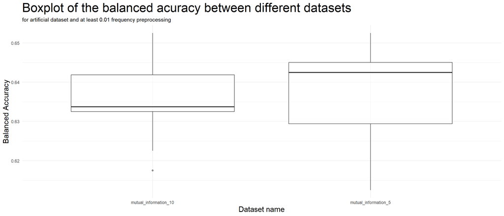

```r
boxplot(freq_01_out$art_metrics, 'artificial', 'at least 0.01 frequency')
```

In this case, using the mutual information was a dead end, as the final results were only slightly better than the MRMR.

# 8 Best models

## 8.1 Spam

As we can see from the table below, the best model was a lightgbm with basic parameters, so we will train this model again with the forester and keep it for the predictions. Additionally, as we can limit ourselves to just one dataset and one engine, we are able to increase the number of random evaluations and count for obtaining better results this way.

```r
kable(freq_01_out$spam_metrics$spam_test_mutual_information_50.csv)
```

|  | name | sensitivity | specificity | balanced_accuracy |
| --- | --- | --- | --- | --- |
| 2 | lightgbm_model | 0.869918699186992 | 0.98989898989899 | 0.929908844542991 |
| 5 | lightgbm_RS_1 | 0.861788617886179 | 0.986111111111111 | 0.923949864498645 |
| 3 | lightgbm_RS_3 | 0.853658536585366 | 0.987373737373737 | 0.920516136979552 |
| 7 | lightgbm_RS_19 | 0.845528455284553 | 0.987373737373737 | 0.916451096329145 |
| 8 | xgboost_RS_26 | 0.83739837398374 | 0.992424242424242 | 0.914911308203991 |
| 4 | lightgbm_RS_21 | 0.83739837398374 | 0.98989898989899 | 0.913648681941365 |
| 6 | lightgbm_RS_15 | 0.821138211382114 | 0.986111111111111 | 0.903624661246613 |
| 9 | ranger_model | 0.796747967479675 | 0.991161616161616 | 0.893954791820645 |
| 10 | ranger_RS_44 | 0.772357723577236 | 0.992424242424242 | 0.882390983000739 |
| 1 | lightgbm_RS_23 | 0.772357723577236 | 0.988636363636364 | 0.8804970436068 |

### 8.1.1 Training

```r
spam_best <- train (data = freq_01_list$spam_train_mutual_information_50.csv,
                    y = 'TARGET',
                    engine = 'lightgbm',
                    verbose = Verbose,
                    train_test_split = Train_test_split,
                    split_seed = Split_seed,
                    bayes_iter = 0,
                    random_evals = 100,
                    advanced_preprocessing = Advanced_preprocessing,
                    metrics = Metrics,
                    sort_by = Sort_by)
```

```r
spam_best_preds   <- predict_new(spam_best, freq_01_list$spam_test_mutual_information_50.csv)
spam_best_metrics <- get_metrics(freq_01_list$spam_test_mutual_information_50.csv$TARGET, spam_best_preds)
kable(spam_best_metrics)
```

|  | name | sensitivity | specificity | balanced_accuracy |
| --- | --- | --- | --- | --- |
| 1 | lightgbm_model | 0.869918699186992 | 0.98989898989899 | 0.929908844542991 |
| 24 | lightgbm_RS_23 | 0.861788617886179 | 0.986111111111111 | 0.923949864498645 |
| 25 | lightgbm_RS_24 | 0.853658536585366 | 0.987373737373737 | 0.920516136979552 |
| 21 | lightgbm_RS_20 | 0.845528455284553 | 0.987373737373737 | 0.916451096329145 |
| 28 | lightgbm_RS_27 | 0.83739837398374 | 0.98989898989899 | 0.913648681941365 |
| 22 | lightgbm_RS_21 | 0.821138211382114 | 0.986111111111111 | 0.903624661246613 |
| 2 | lightgbm_RS_1 | 0.804878048780488 | 0.988636363636364 | 0.896757206208426 |
| 8 | lightgbm_RS_7 | 0.796747967479675 | 0.98989898989899 | 0.893323478689332 |
| 10 | lightgbm_RS_9 | 0.788617886178862 | 0.991161616161616 | 0.889889751170239 |
| 9 | lightgbm_RS_8 | 0.772357723577236 | 0.988636363636364 | 0.8804970436068 |
| 12 | lightgbm_RS_11 | 0.747967479674797 | 0.986111111111111 | 0.867039295392954 |
| 5 | lightgbm_RS_4 | 0.739837398373984 | 0.987373737373737 | 0.863605567873861 |
| 14 | lightgbm_RS_13 | 0.650406504065041 | 0.986111111111111 | 0.818258807588076 |
| 4 | lightgbm_RS_3 | 0.552845528455285 | 0.992424242424242 | 0.772634885439764 |
| 16 | lightgbm_RS_15 | 0.552845528455285 | 0.992424242424242 | 0.772634885439764 |
| 13 | lightgbm_RS_12 | 0.544715447154472 | 0.994949494949495 | 0.769832471051983 |
| 27 | lightgbm_RS_26 | 0.40650406504065 | 0.983585858585859 | 0.695044961813254 |
| 18 | lightgbm_RS_17 | 0.252032520325203 | 1 | 0.626016260162602 |
| 20 | lightgbm_RS_19 | 0.227642276422764 | 1 | 0.613821138211382 |
| 6 | lightgbm_RS_5 | 0.195121951219512 | 0.998737373737374 | 0.596929662478443 |
| 17 | lightgbm_RS_16 | 0.016260162601626 | 1 | 0.508130081300813 |
| 7 | lightgbm_RS_6 | 0.016260162601626 | 0.998737373737374 | 0.5074987681695 |
| 3 | lightgbm_RS_2 | 0 | 1 | 0.5 |
| 11 | lightgbm_RS_10 | 0 | 1 | 0.5 |
| 15 | lightgbm_RS_14 | 0 | 1 | 0.5 |
| 19 | lightgbm_RS_18 | 0 | 1 | 0.5 |
| 23 | lightgbm_RS_22 | 0 | 1 | 0.5 |
| 26 | lightgbm_RS_25 | 0 | 1 | 0.5 |

As we can see, in this case the additional number of random searched models didn’t help us with obtaining better results, so we will stick to the lightgbm_model

### 8.1.2 Predictions

```r
spam_validation <- read.csv2('data/spam_valid_preprocessed.csv', sep = ',')
spam_validation <- spam_validation[-1]
# The forester due to a big requires an y coloumn to work, even though it doesn't use this columns values.
spam_validation$TARGET <- c(rep(0, 500), rep(1, 500))
```

```r
spam_best_preds          <- predict_new(spam_best, spam_validation)
spam_final_preds_probs   <- round(spam_best_preds$lightgbm_model, 7)
spam_final_preds_labels  <- ifelse(spam_best_preds$lightgbm_model > 0.5, 1, 0)
```

```r
fwrite(list(spam_final_preds_probs), 'outcomes/spam_final_preds_probs.txt')
fwrite(list(spam_final_preds_labels), 'outcomes/spam_final_preds_labels.txt')
```

## 8.2 Artificial

In this case we will also train more models, and we will limit ourselves to the ranger engine, as it proved to be the best one.

```r
kable(raw_list_out$art_metrics$artificial_test_boruta_20.csv)
```

|  | name | sensitivity | specificity | balanced_accuracy |
| --- | --- | --- | --- | --- |
| 9 | ranger_RS_20 | 0.875 | 0.875 | 0.875 |
| 4 | ranger_RS_11 | 0.875 | 0.87 | 0.8725 |
| 8 | ranger_model | 0.87 | 0.87 | 0.87 |
| 1 | ranger_RS_10 | 0.865 | 0.87 | 0.8675 |
| 7 | ranger_RS_22 | 0.875 | 0.86 | 0.8675 |
| 5 | ranger_RS_24 | 0.86 | 0.865 | 0.8625 |
| 10 | ranger_RS_46 | 0.855 | 0.87 | 0.8625 |
| 3 | ranger_RS_30 | 0.86 | 0.86 | 0.86 |
| 6 | ranger_RS_13 | 0.855 | 0.86 | 0.8575 |
| 2 | ranger_RS_12 | 0.85 | 0.845 | 0.8475 |

### 8.2.1 Training

```r
art_best <- train (data = raw_list$artificial_train_boruta_20.csv,
                    y = 'TARGET',
                    engine = 'ranger',
                    verbose = Verbose,
                    train_test_split = Train_test_split,
                    split_seed = Split_seed,
                    bayes_iter = 0,
                    random_evals = 100,
                    advanced_preprocessing = Advanced_preprocessing,
                    metrics = Metrics,
                    sort_by = Sort_by)
```

```r
art_best_preds   <- predict_new(art_best, raw_list$artificial_test_boruta_20.csv)
art_best_metrics <- get_metrics(raw_list$artificial_test_boruta_20.csv$TARGET, art_best_preds)
kable(art_best_metrics)
```

|  | name | sensitivity | specificity | balanced_accuracy |
| --- | --- | --- | --- | --- |
| 34 | ranger_RS_33 | 0.875 | 0.88 | 0.8775 |
| 39 | ranger_RS_38 | 0.88 | 0.875 | 0.8775 |
| 75 | ranger_RS_74 | 0.88 | 0.875 | 0.8775 |
| 1 | ranger_model | 0.87 | 0.87 | 0.87 |
| 42 | ranger_RS_41 | 0.865 | 0.875 | 0.87 |
| 65 | ranger_RS_64 | 0.87 | 0.87 | 0.87 |
| 11 | ranger_RS_10 | 0.855 | 0.88 | 0.8675 |
| 60 | ranger_RS_59 | 0.86 | 0.875 | 0.8675 |
| 62 | ranger_RS_61 | 0.87 | 0.865 | 0.8675 |
| 63 | ranger_RS_62 | 0.875 | 0.86 | 0.8675 |
| 36 | ranger_RS_35 | 0.865 | 0.865 | 0.865 |
| 31 | ranger_RS_30 | 0.86 | 0.865 | 0.8625 |
| 24 | ranger_RS_23 | 0.855 | 0.86 | 0.8575 |
| 76 | ranger_RS_75 | 0.85 | 0.865 | 0.8575 |
| 19 | ranger_RS_18 | 0.85 | 0.86 | 0.855 |
| 35 | ranger_RS_34 | 0.85 | 0.86 | 0.855 |
| 56 | ranger_RS_55 | 0.84 | 0.87 | 0.855 |
| 77 | ranger_RS_76 | 0.86 | 0.85 | 0.855 |
| 22 | ranger_RS_21 | 0.855 | 0.85 | 0.8525 |
| 67 | ranger_RS_66 | 0.85 | 0.855 | 0.8525 |
| 71 | ranger_RS_70 | 0.845 | 0.86 | 0.8525 |
| 21 | ranger_RS_20 | 0.85 | 0.85 | 0.85 |
| 17 | ranger_RS_16 | 0.845 | 0.85 | 0.8475 |
| 25 | ranger_RS_24 | 0.85 | 0.845 | 0.8475 |
| 80 | ranger_RS_79 | 0.83 | 0.85 | 0.84 |
| 23 | ranger_RS_22 | 0.855 | 0.82 | 0.8375 |
| 69 | ranger_RS_68 | 0.805 | 0.87 | 0.8375 |
| 53 | ranger_RS_52 | 0.82 | 0.85 | 0.835 |
| 70 | ranger_RS_69 | 0.82 | 0.85 | 0.835 |
| 54 | ranger_RS_53 | 0.82 | 0.845 | 0.8325 |

[output cut: 52 more lines]

### 8.2.2 Predictions

```r
art_validation <- read.csv2('data/artificial_valid_preprocessed.csv', sep = ',')
art_validation <- art_validation[-1]
# The forester due to a big requires an y coloumn to work, even though it doesn't use this columns values.
art_validation$TARGET <- c(rep(-1, 300), rep(1, 300))
```

```r
art_best_preds          <- predict_new(art_best, art_validation)
art_final_preds_probs   <- round(art_best_preds$ranger_RS_33, 7)
art_final_preds_labels  <- ifelse(art_best_preds$ranger_RS_33 > 0.5, 1, 0)
```

```r
fwrite(list(art_final_preds_probs), 'outcomes/art_final_preds_probs.txt')
fwrite(list(art_final_preds_labels), 'outcomes/art_final_preds_labels.txt')
```